# STAT 405/705 Assignment 1

Answers

Jan 2019

If in a question I refer to a function that we have not seen in class, then use the help facility in R to find out about it. Insert your answers and the R code you used to generate it, beneath each question. Even though for some questions you could find the answer “by inspection”, for this homework you need to write code to explicitly get the answers.

My birthday is September 2nd, 1994 (I wish). Using the convention MMDDYYYY, then my birthday number is 09021994

## Q1.

#### a. Store your birthday number into a numeric variable called “bday”.

#### (It doesn’t matter if your birthday number starts with a leading 0 - just include it.)

```r
bday <- 01051995
```

#### Now write code to find and print the answer for all parts:

#### b. The fifth root of your birthday number.

```r
bday^(1/5)
```

```
## [1] 16.01042
```

#### c. The log base 2 of your birthday number.

```r
log2(bday)
```

```
## [1] 20.0047
```

#### d. The modulus of your birthday number, base 9.

```r
bday%%9
```

```
## [1] 3
```

#### e. Write code to create and store in a variable the first 1000 terms in the sequence:

#### (Hint: create two simpler sequences that you then multiply elementwise).

#### {1, -1/3, 1/5, -1/7, 1/9, -1/11 … }

```r
seq.1 <- 1/(seq(1000)*2-1)
seq.2 <- c(1,-1)
seq.ans <- seq.1*seq.2
```

#### f. Take the sequence in part e, sum it and multiply by 4. Print the answer.

```r
sum(seq.ans)*4
```

```
## [1] 3.140593
```

## Q2.

#### a. Create the two vectors of numbers alpha = (1000, 980, 960,…,200)

#### beta = (150, 165, 180, …, 750)

```r
alpha <- seq(1000,200,-20)
beta <- seq(150,750,15)
```

#### b. What is the sum of the elementwise product of the two vectors?

```r
prod <- alpha*beta
sum(prod)
```

```
## [1] 9348000
```

#### c. What is the maximum value in the vector containing the elementwise products?

```r
max(prod)
```

```
## [1] 270000
```

#### d. What is/are the indices (position in the vector) of the maximum value found in part c?

```r
which(prod == max(prod))
```

```
## [1] 21
```

```r
# or
which.max(prod)
```

```
## [1] 21
```

#### e. How many of the elements of the elementwise product vector are strictly greater than 220000?

```r
sum(prod>220000)
```

```
## [1] 25
```

#### f. How many of the elements of the elementwise product vector are strictly between 180000 and 240000?

```r
sum( prod>180000 & prod<240000)
```

```
## [1] 14
```

## Q3.

#### a. Set the random number seed as your birthday number

```r
set.seed(bday)
```

#### b. Create two vectors, named x and y of standard normal random variables, each of length 1000000.

```r
x <- rnorm(1000000)
y <- rnorm(1000000)
```

#### c. Create a third vector, called z, containing the elementwise square root of the sum of the squares of the elements.

#### That is, if you call the first elements x1 and y1, etc., you need to calculate

#### x1,y1 —>>>> sqrt(x1^2 + y1^2)

#### x2,y2 —>>>> sqrt(x2^2 + y2^2)

#### x3,y3 —>>>> sqrt(x3^2 + y3^2)

#### and so on.

```r
z <- sqrt(x^2+y^2)
```

#### d. Find the average of the elements in the z vector

```r
mean(z)
```

```
## [1] 1.251744
```

#### e. Square the average and double. Print the result.

```r
mean(z)^2*2
```

```
## [1] 3.133725
```

## Q4.

#### a. Enter the following 5 x 5 matrix into R and call it “mat.q4”

#### (0 0 0 0 1

#### 0 0 0 1 4

#### 0 0 1 3 6

#### 0 1 2 3 4

#### 1 1 1 1 1)

#### Label the columns as A, B, C, D and E and the rows as Alpha, Beta, Gamma, Delta and Epsilon.

```r
vec <- c(0,0,0,0,1,0,0,0,1,4,0,0,1,3,6,0,1,2,3,4,1,1,1,1,1)
mat.q4 <- matrix(vec,nrow = 5, ncol = 5, byrow = T)
colnames(mat.q4) <- c("A","B","C","D","E")
rownames(mat.q4) <- c("Alpha", "Beta", "Gamma", "Delta", "Epsilon")
```

#### b. Print the matrix and paste the printed output below.

```r
mat.q4
```

```
##         A B C D E
## Alpha   0 0 0 0 1
## Beta    0 0 0 1 4
## Gamma   0 0 1 3 6
## Delta   0 1 2 3 4
## Epsilon 1 1 1 1 1
```

#### c. Extract and print the submatrix corresponding to the third row, and the fourth and fifth columns. Make sure that what you extract is indeed a matrix and not a vector.

```r
mat.q4[3,c(4,5),drop=F]
```

```
##       D E
## Gamma 3 6
```

#### d. Find the transpose of the matrix entered in part a (the transpose swaps the rows and columns).

```r
mat.q4.t <- t(mat.q4)
```

#### e. Multiple the original matrix (on the left) by its transpose (on the right)

#### (use, matrix multiplication, “%*%“, not element-wise) and store the result.

```r
mat.prod <- mat.q4%*%mat.q4.t
```

#### f. Find and print the inverse of the matrix created in part e.

```r
mat.inv <- solve(mat.prod)
mat.inv
```

```
##         Alpha Beta Gamma Delta Epsilon
## Alpha      70  -35    15    -5       1
## Beta      -35   20   -10     4      -1
## Gamma      15  -10     6    -3       1
## Delta      -5    4    -3     2      -1
## Epsilon     1   -1     1    -1       1
```

#### g. Find and print the sum of the elements of the leading (top left to bottom right) diagonal of the inverse matrix.

```r
sum(diag(mat.inv))
```

```
## [1] 99
```

## Q5.

#### A market research company asked respondents the question:

#### “Would you recommend this product to a friend?”

#### People answered on a 1 through 5 numeric scale, where:

#### 1 was “definitely no”

#### 2 was “probably no”

#### 3 was “maybe”

#### 4 was “probably yes”

#### 5 was “definitely yes”

#### Analysts needed to recode this numeric variable into a

#### three-level ordered factor, with levels:

#### “definitely no” if they had answered with a 1.

#### “unsure” if they had answered with 2, 3 or 4.

#### “definitely yes” if they had answered with a 5.

#### Here’s the raw data:

raw.scores <- c(1, 2, 1, 4, 4, 5, 2, 1, 1, 5, 5, 1, 3, 3, 3, 1, 4, 2, 2, 2, 3, 1, 1, 1, 3, 2, 3, 1, 4, 5)

#### a. Write code to create and store a logical vector that takes on the value TRUE if the raw score was either a 2 or a 3 or a 4 and FALSE otherwise.

```r
raw.scores <- c(1, 2, 1, 4, 4, 5, 2, 1, 1, 5,
                5, 1, 3, 3, 3, 1, 4, 2, 2, 2,
                3, 1, 1, 1, 3, 2, 3, 1, 4, 5)
logical.vec <- (raw.scores == 2) | (raw.scores == 3) | (raw.scores == 4)
```

#### b. Using the logical vector from part a, replace the values 2, 3 and 4 with the value 3. Call this new numeric vector “mod.scores”. At this point mod.scores should only contain the values 1, 3 and 5.

```r
mod.scores <- logical.vec*3 + (1-logical.vec)*raw.scores
```

#### c. Create and store from “mod.scores” an ordered factor variable from the modified data with the labels “definitely no”, “unsure”, and “definitely yes”. “definitely no” should be the lowest value and “definitely yes” the highest of the factor.

```r
fac.scores <- factor(mod.scores,
 levels = c(1,3,5),
 labels = c("definitely no","unsure","definitely yes"),
 ordered = TRUE)
```

#### d. Summarize the data with the “table” command and paste the output below.

```r
tab.scores <- table(fac.scores)
```

[output not shown]

#### e. Write code to identify and print which of the three new levels occurred most frequently.

```r
names(which.max(tab.scores))
```

```
## [1] "unsure"
```

#### aside: you can use the table output as input to the “pie” function which makes a pie chart.

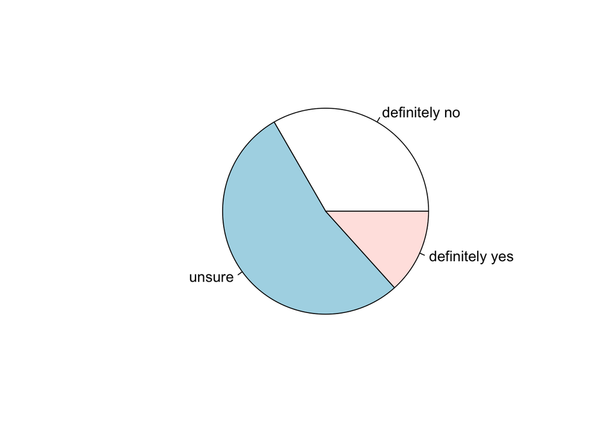

```r
pie(tab.scores)
```

## Q6.

#### a. What is a key difference between the list extraction operators [ and $?

```r
# The extraction operator [ only allows numerical indices while $ only allows a character string.
# Operator [ lets you extract multiple entries at once, while operator $
# only lets you extract one. Also when [ and $ are used to extract a single
# list element, [ stores the extracted element inside a length-one list,
# while $ does not.
```

#### b. Reset the random number seed to your birthday seed.

```r
set.seed(bday)
```

#### Paste the following code into R

```r
my.list <- list(A = c(sample(10,10,replace=TRUE)), B = matrix(rnorm(49),ncol=7),
                ALPHA = list(MU = matrix(sample(10,81,replace=TRUE),ncol=9), NU = matrix(rnorm(81),ncol=9)))
```

#### c. Write code to extract and print the value of the (6,2) element in the B matrix.

```r
my.list[["B"]][6,2]
```

```
## [1] 1.104113
```

```r
# or
my.list$B[6,2]
```

```
## [1] 1.104113
```

```r
# or
my.list[[2]][6,2]
```

```
## [1] 1.104113
```

#### d. Write code to extract and find the sum of all of the elements in the matrix product (%*%) of the two matrices MU and NU.

```r
sum(my.list[["ALPHA"]][["MU"]]%*%my.list[["ALPHA"]][["NU"]])
```

```
## [1] -460.3949
```

#### e. Rename the element called “B”, as “D”, and paste both the command you used and the output from the names() command to prove that you did it successfully.

```r
names(my.list)[which(names(my.list) == "B")]<-"D"
names(my.list)
```

```
## [1] "A"     "D"     "ALPHA"
```

## Q7.

#### a. Set the random number seed to your birthday number again.

```r
set.seed(bday)
```

#### b. Create a 400 x 10000 matrix of standard normals (mean = 0, sd = 1).

```r
rmat <- matrix(rnorm(400*10000), nrow = 400, ncol = 10000)
```

#### c. Using the apply function, find the mean of each column of the matrix.

```r
meancols <- apply(rmat, MARGIN = 2, FUN = mean)
```

#### d. Find and report the standard deviation (R command “sd”) of these 10000 column means. What you have just done is empirically estimate the standard error of the sample mean, when the sample mean is based on a sample of size n = 400.

```r
sd(meancols)
```

```
## [1] 0.05008554
```